# Activity Monitoring

### Part3

- total number of missing values
- impute the missing data
- redo Part1 with the new data set
- what is the impact of data filling?

```r
sum(is.na(data)) #total number of missing data
```

```
## [1] 2304
```

```r
sapply(data, function(x) sum(is.na(x))) #by variable
```

```
##    steps     date interval
##     2304        0        0
```

All the missing data is in the first column, steps

Impute the missing values with the average number of steps for the entire dataframe

```r
imp <- mean(data$steps,na.rm=T)
data1 <- data #copy the original data
data1[is.na(data),'steps'] <- imp
```

Double check to see if there are any missing data left:

```r
sum(is.na(data1))
```

```
## [1] 0
```

Histogram:

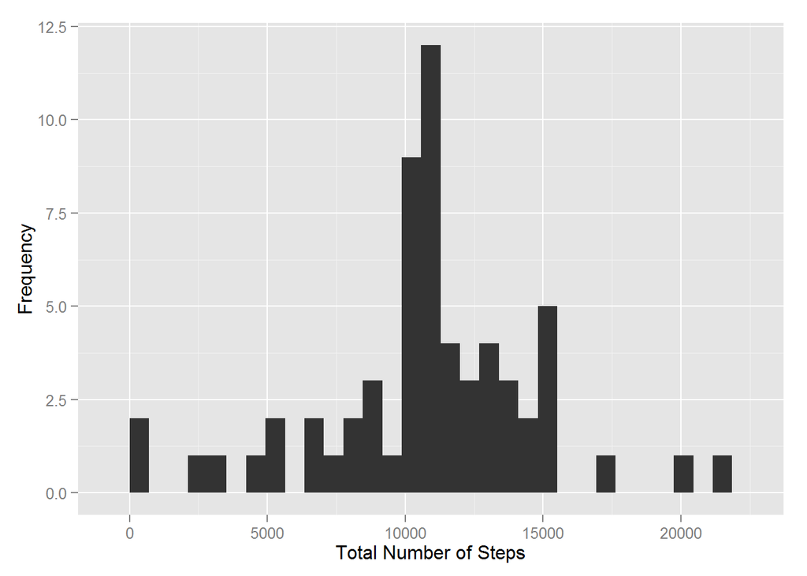

```r
tsum1<- tapply(data1$steps,data1$date,sum,na.rm=T)
dfsum1<-data.frame(tsum1)
p3<- ggplot(data=dfsum1,aes(x=tsum1))
p3<- p3+geom_histogram()
p3<- p3+labs(x='Total Number of Steps',y='Frequency')
p3
```

the peak of the plot corresponds to the mean of the dataset because all the missing values were replaced with the mean of the dataset.

Mean and median:

```r
outmat1 <- matrix(nrow=length(unique(data1$date)),ncol=2,dimnames = list(as.character(unique(data1$date)),c('mean','median')))
mm1 <- sapply(list('mean','median'),function(x){ tmp<-tapply(data1$steps, data1$date, x,na.rm=T); outmat1[,x]<<- tmp})
outmat1 #mean and median per day
```

```
##               mean median
## 2012-10-01 37.3826  37.38
## 2012-10-02  0.4375   0.00
## 2012-10-03 39.4167   0.00
## 2012-10-04 42.0694   0.00
## 2012-10-05 46.1597   0.00
## 2012-10-06 53.5417   0.00
## 2012-10-07 38.2465   0.00
## 2012-10-08 37.3826  37.38
## 2012-10-09 44.4826   0.00
## 2012-10-10 34.3750   0.00
## 2012-10-11 35.7778   0.00
## 2012-10-12 60.3542   0.00
## 2012-10-13 43.1458   0.00
## 2012-10-14 52.4236   0.00
## 2012-10-15 35.2049   0.00
## 2012-10-16 52.3750   0.00
## 2012-10-17 46.7083   0.00
## 2012-10-18 34.9167   0.00
## 2012-10-19 41.0729   0.00
## 2012-10-20 36.0938   0.00
## 2012-10-21 30.6285   0.00
## 2012-10-22 46.7361   0.00
## 2012-10-23 30.9653   0.00
## 2012-10-24 29.0104   0.00
## 2012-10-25  8.6528   0.00
## 2012-10-26 23.5347   0.00
## 2012-10-27 35.1354   0.00
## 2012-10-28 39.7847   0.00
## 2012-10-29 17.4236   0.00
## 2012-10-30 34.0938   0.00
## 2012-10-31 53.5208   0.00
## 2012-11-01 37.3826  37.38
## 2012-11-02 36.8056   0.00
## 2012-11-03 36.7049   0.00
## 2012-11-04 37.3826  37.38
## 2012-11-05 36.2465   0.00
## 2012-11-06 28.9375   0.00
## 2012-11-07 44.7326   0.00
## 2012-11-08 11.1771   0.00
## 2012-11-09 37.3826  37.38
## 2012-11-10 37.3826  37.38
## 2012-11-11 43.7778   0.00
## 2012-11-12 37.3785   0.00
## 2012-11-13 25.4722   0.00
## 2012-11-14 37.3826  37.38
## 2012-11-15  0.1424   0.00
## 2012-11-16 18.8924   0.00
## 2012-11-17 49.7882   0.00
## 2012-11-18 52.4653   0.00
## 2012-11-19 30.6979   0.00
## 2012-11-20 15.5278   0.00
## 2012-11-21 44.3993   0.00
## 2012-11-22 70.9271   0.00
## 2012-11-23 73.5903   0.00
## 2012-11-24 50.2708   0.00
## 2012-11-25 41.0903   0.00
## 2012-11-26 38.7569   0.00
## 2012-11-27 47.3819   0.00
## 2012-11-28 35.3576   0.00
## 2012-11-29 24.4688   0.00
## 2012-11-30 37.3826  37.38
```

```r
mean(dfsum1$tsum1) #mean of total number of steps for the entire dataset
```

```
## [1] 10766
```

```r
median(dfsum1$tsum1) #median of total number of steps for the entire dataset
```

```
## [1] 10766
```

let’s compare the summaries of the mean:

```r
summary(outmat[,'mean'])
```

```
##    Min. 1st Qu.  Median    Mean 3rd Qu.    Max.    NA's
##    0.14   30.70   37.40   37.40   46.20   73.60       8
```

```r
summary(outmat1[,'mean'])
```

```
##    Min. 1st Qu.  Median    Mean 3rd Qu.    Max.
##    0.14   34.10   37.40   37.40   44.50   73.60
```

### Part4

Are there differences in activity patterns between weekdays and weekends?  
* create a new variable for weekdays  
* make a panel plot

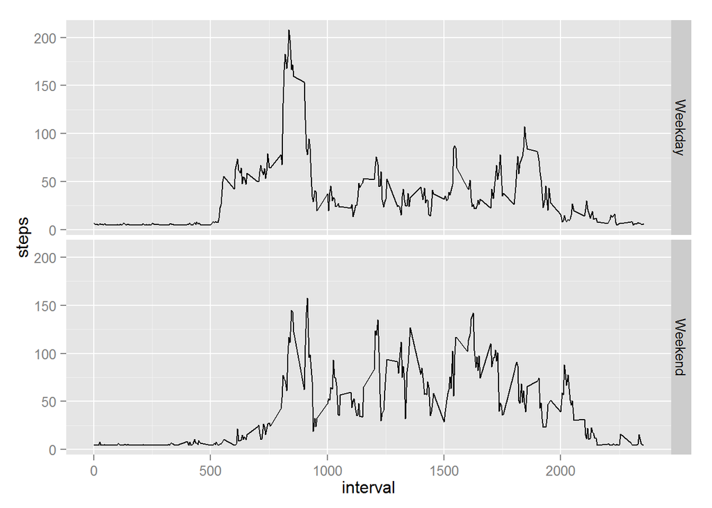

```r
data1$wday <- weekdays(data1$date)
data1$wday <- ifelse(data1$wday %in% c('Saturday','Sunday'),'Weekend','Weekday')
t1<-aggregate(steps~interval+wday,data=data1,mean,na.rm=T)
p4 <- ggplot(data=t1,aes(x=interval,y=steps))
p4 <- p4+geom_line()+facet_grid(wday~.)
p4
```